# Overlapping_pathway_DESeq2

Author

Pakorn Sagulkoo

After we carried out psedobulk gene expression analysis and GSEA for several RT scRNA-sequences datasets, we will evaluate the consistency of functional enrichment results across those studiescalculated from Pseudobulk analysis using DESeq2. Then we will explore overlapping enrichment terms among those studies.

## Import the relevant packages and set working path directory

```r
# Import the relavant packages
library(UpSetR)
library(dplyr)
library(tibble)
library(stringr)
library(ggplot2)
library(ggrepel)
```

```r
# Check root path
here::here()
```

```
[1] "/mnt/hp-storage/users/pakorns"
```

## Define paths

```r
# Define paths to load and save files
path_to_single_cell_analysis <- here::here("scRNAseq/systematic_review")
```

## Load data and functions

```r
# Source functions
source(here::here("bin/utils.R"))
```

## Define names used in files and labels

```r
# List file names of all studies
study.lst <- c("1-Penter_2021_GSE165087", "2-Nadeu_2022", "3-Hing_2022_GSE205704", "4-Parry_2023b", "5-Rigo_2024")
study.lst
```

```
[1] "1-Penter_2021_GSE165087" "2-Nadeu_2022"
[3] "3-Hing_2022_GSE205704"   "4-Parry_2023b"
[5] "5-Rigo_2024"
```

```r
# Create names for list later
names.lst <- sub(
  "^\\d+-([A-Za-z]+)_([0-9]{4}[A-Za-z]?).*$",  # capture name and year
  "\\1(\\2)",                         # output as Name(Year)
  study.lst
)
names.lst
```

```
[1] "Penter(2021)" "Nadeu(2022)"  "Hing(2022)"   "Parry(2023b)" "Rigo(2024)"
```

```r
# Extract only name of studies
study_names <- sub("^\\d+-([^_0-9]+).*", "\\1", study.lst)
study_names
```

```
[1] "Penter" "Nadeu"  "Hing"   "Parry"  "Rigo"
```

We performed GSEA using five main terms such as Hallmark, GO:BP, KEGG, Reactome, and WikiPath. We will identify these significant terms in both up- and downregulation.

## Overlapping of GSEA results based on DESeq2-based pseudobulk analysis

### Hallmark

```r
# Import the results from all studies and collect in a list
path_to_download <- str_c(path_to_single_cell_analysis, "/", study.lst, "/pseudo_bulk_deseq2/", study_names, "_deseq2_hm_gsea.rds")
path_to_download <- path_to_download
hm_gsea.lst <- purrr::pmap(
  list(path_to_download),
  function(path){
    gsea <- readRDS(path)
    return(gsea)
  }
)
names(hm_gsea.lst) <- names.lst
```

#### Upregulated terms

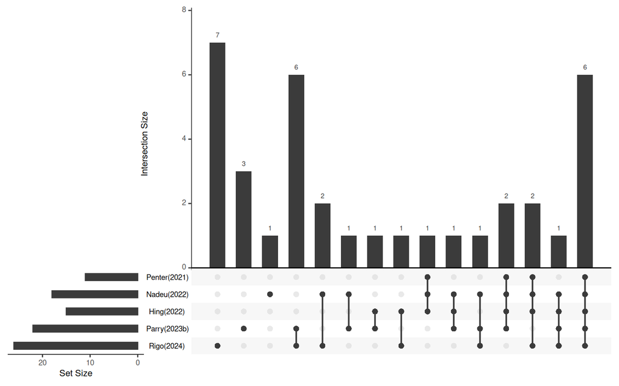

```r
# Extract adjusted significant upregulated hallmark terms
sig_term.lst <- purrr::pmap(
  list(hm_gsea.lst),
  function(gsea){
    selected_term <- gsea@result[gsea@result$NES > 0, "ID"]
    return(selected_term)
  }
)

# Reorder the list first
sig_term.lst <- sig_term.lst %>%
  purrr::discard(~ length(.x) == 0) %>%   # drop empty ones
  rev()                                   # reverse order

# Convert to UpSetR input
upset_data <- fromList(sig_term.lst)

# Plot UpSetR
upset(
  upset_data,
  sets = colnames(upset_data),      # ensures only these sets
  keep.order = TRUE,
  nintersects = NA
)
```

In comparison with the results from Seurat-based pseudobulk approach, DESeq2-based result has a higher common terms than the previous approach. Then we will identify those common terms. This will be explored using set operations and UpSet plots. For example, if we have three sets (A, B, and C), the expression ‘members from A ∩ B’ refers to terms that are present in both A and B but excluded from those present in all three sets (A, B, and C).

```r
# Find common hallmark terms in all studies
five_common_hm <- Reduce(intersect, sig_term.lst)
five_common_hm
```

```
[1] "HALLMARK_OXIDATIVE_PHOSPHORYLATION" "HALLMARK_FATTY_ACID_METABOLISM"
[3] "HALLMARK_G2M_CHECKPOINT"            "HALLMARK_MTORC1_SIGNALING"
[5] "HALLMARK_E2F_TARGETS"               "HALLMARK_MYC_TARGETS_V1"
```

```r
# Find common hallmark terms in four studies: Nadeu, Hing, Parry, and Rigo
four_common_hm <- Reduce(intersect, sig_term.lst[names(sig_term.lst) != "Penter(2021)"])
setdiff(four_common_hm, five_common_hm)
```

```
[1] "HALLMARK_CHOLESTEROL_HOMEOSTASIS"
```

```r
# Find common hallmark terms in four studies: Penter, Nadeu, Hing, and Rigo
four_common_hm <- Reduce(intersect, sig_term.lst[names(sig_term.lst) != "Parry(2023b)"])
setdiff(four_common_hm, five_common_hm)
```

```
[1] "HALLMARK_ADIPOGENESIS" "HALLMARK_DNA_REPAIR"
```

```r
# Find common hallmark terms in four studies: Penter, Nadeu, Hing, and Parry
four_common_hm <- Reduce(intersect, sig_term.lst[names(sig_term.lst) != "Rigo(2024)"])
setdiff(four_common_hm, five_common_hm)
```

```
[1] "HALLMARK_MYC_TARGETS_V2" "HALLMARK_GLYCOLYSIS"
```

These common upregulated hallmark terms were related to OXOSPHOS, glucose and lipid metabolisms, E2F and Myc signalling, and Cell cycle and proliferation.